# Selection

2024-12-13

#### Note

Following includes codes used to generate an generate alignments of coding sequences and then run selection analysis

# 1 Introduction

This markdown file documents selection tests used to identify genes selected in short-tarsi taxa. We used two approaches one using TOGA to generate coding sequence alignments for the 78 species in our study and then using aBSREL to look for evidence of positive selection. For the second approach we used population resequencing data to perform a MK test.

We used the Hal file generated from cactus: see [cactus doc](https://subirshakya.github.io/projects_rmarkdown/cactus.html). For the reference species we used Galgal7b refseq gff file: [here](https://ftp.ncbi.nlm.nih.gov/genomes/refseq/vertebrate_other/Gallus_gallus/latest_assembly_versions/GCF_016699485.2_bGalGal1.mat.broiler.GRCg7b/GCF_016699485.2_bGalGal1.mat.broiler.GRCg7b_genomic.gff.gz)

# 2 TOGA and aBSREL

## 2.1 TOGA

We used TOGA (see Kirilenko et al. (2023)) to generate orthologous sequences for the 78 species. To prepare the data for TOGA, we followed the steps outlined [here](https://github.com/harvardinformatics/GenomeAnnotation-TOGA).

### 2.1.1 Gather files for reference genome

```bash
#bash

#Generate file containing chromosome lenghts for galgal7 assembly
python GenomeAnnotation-TOGA/utilities/WriteChromLengthBedFromFasta.py galgal7 Gallus_gallus_GCF016699485.fna

#Gather only CDS
gffread galgal7b.gff -g Gallus_gallus_GCF016699485.fna -F -C -o galgal7b_cds.gff

#Get isoform information file
awk -F"\t" '$3=="mRNA"{print $9}' galgal7b_cds.gff | \
    awk -F";" '{print $3"\t"$1}' | \
    sed 's/gene_name=//g' | \
    sed 's/ID=//g' > galgal7b_isoform.tsv

#convert gff to GenePred
gff3ToGenePred galgal7b.gff galgal7b.GenePred

#convert GenePred to bed
genePredToBed galgal7b.GenePred galgal7b.bed

#Keep only CDS in bed
python GenomeAnnotation-TOGA/utilities/FilterAnnotationBedForCDS.py galgal7b_isoform.tsv galgal7b.bed

#Final file is CDS_galgal7b.bed
```

### 2.1.2 Prepare Genomes to Map galgal7b CDS

```bash
#bash

#Create array of all species
files=( $(ls /n/holylfs05/LABS/informatics/Users/sshakya/genomes_cactus/snakemake_out/*.fna) )

#Get scaffold length files for each species
#Convert fasta to 2bit
for i in ${files[@]};
do
        fbname=$(basename "$i" .fna)
        python GenomeAnnotation-TOGA/utilities/WriteChromLengthBedFromFasta.py chrom_length_bed/${fbname} $i
        faToTwoBit $i 2bit/${fbname}.2bit
done

#Manually removed the two gallus gallus genomes
#Use halLiftover to convert hal to psl
#Convert psl to positive strand
#use axtChain to create chain files from PSL
files=( $(ls chrom_length_bed/*.bed) )

for i in ${files[@]};
do
       fbname=$(basename $i _chromlengths.bed)
       species=$(echo $fbname | awk -F_ '{print $1"_"$2}')
       halLiftover --outPSL ../all_birds_new.hal $species $i Gallus_gallus7 psl/${species}_galgal7.psl
       pslPosTarget psl/${species}_galgal7.psl pos_psl/${species}_galgal7.psl
       axtChain -psl -verbose=0 -linearGap=loose pos_psl/${species}_galgal7.psl 2bit/${fbname}.2bit \
          Gallus_gallus_GCF016699485.2bit chain/${species}_galgal7.chain
done
```

### 2.1.3 Run TOGA

TOGA was run with 500 parallel processes per species

```bash
#bash

files=( $(ls chrom_length_bed/*.bed) )

for i in ${files[@]};
do
        fbname=$(basename $i _chromlengths.bed)
        species=$(echo $fbname | awk -F_ '{print $1"_"$2}')
        ~/TOGA/toga.py chain/${species}_galgal7.chain \
                        galgal7b_new.bed \
                        Gallus_gallus_GCF016699485.2bit \
                        2bit/$fbname.2bit \
                        --kt \
                        --pn toga_run/$fbname \
                        -i galgal7b_isoform.tsv \
                        --nc ~/TOGA/nextflow_config_files/ \
                        --cb 10,100 \
                        --cjn 500
done
```

## 2.2 Process TOGA output

### 2.2.1 Gather TOGA output files

First we gather all output files. TOGA failed for two species *Eudyptes filholi* and *Eudyptes moseleyi* and were subsequently omitted from the selection analysis

```bash
#bash

#The main toga output is in the orthology_classification.tsv file

files=( $(ls chrom_length_bed/*.bed) )

for i in ${files[@]};
do
  cp toga_run/${i}/orthology_classification.tsv orthology_files/
  mv orthology_files/orthology_classification.tsv orthology_files/${i}.tsv
done
```

### 2.2.2 Compile list of one-to-one orthologous loci

Next we compiled a dataframe identifying only single copy orthologs. * We included all genes labeled one2one with galgal7b * We also included all genes labeled one2zero * For genes labeled one2many we dropped the species with the multiple hits and only kept single copy genes * We kept only one transcript (largest) per gene * We dropped any gene with less than 15 species

```r
#R

chicken <- read.table("galgal7b_isoform.tsv",
                      sep = "\t", header = F, col.names = c("gene", "transcript"))
chicken_bed <- read.table("galgal7b.bed", sep = "\t", header = F)
chicken_bed$length <- unlist(lapply(lapply(strsplit(chicken_bed$V11,split = ","), as.integer), sum))
chicken <- merge(chicken, chicken_bed[,c("V4", "length")], by.x="transcript", by.y="V4", all.x = T, all.y = F)

species <- read.table("species_list.txt", sep = "\t", header = F)
for (specie in species$V1){
  print(specie)
  try({
    transcripts <- read.table(paste("orthology_files/", specie, ".tsv", sep = ""), sep = "\t", header = T)
    #keep only one to one
    transcripts <- subset(transcripts, orthology_class %in% c("one2one","one2zero", "one2many"))
    transcripts <- transcripts[!duplicated(transcripts[,1:2]),]
    transcripts$q_gene[transcripts$orthology_class %in% "one2many"] <- "None"
    transcripts$q_transcript[transcripts$orthology_class %in% "one2many"] <- "None"
    colnames(transcripts)[3:4] <- paste(colnames(transcripts)[3:4], specie, sep = ".")
    chicken <- merge(chicken, transcripts[,2:4], by.x = "transcript", by.y="t_transcript", all.x = F, all.y = F)
  })
}

chicken <- chicken[order(chicken$gene, -chicken$length), ]
chicken <- chicken[!duplicated(chicken$gene),]
chicken$none_count <- rowSums(chicken == "None")

#We filtered genes with less than 15 species represented
chicken2 <- subset(chicken, none_count < 30)
chicken2 <- chicken2[!duplicated(chicken2$gene),]

write.table(chicken2[,c(1:153)], "one2one_orthos.txt", sep = "\t", row.names = F, col.names = T, quote = F)
```

## 2.3 Run Selection Analysis

### 2.3.1 Gather each gene in a single fasta file

We ended up with *10435* genes.

```python
!usr/bin/python

from Bio import SeqIO
import pandas as pd
import os

class orthologues:
    def __init__(self):
        self.seqs = []

def main():
    one2one_df = pd.read_table("one2one_orthos.txt")
    species = [one2one_df.columns[x].split(".")[1] for x in range(3,len(one2one_df.columns),2)]
    genes = {}

    #Create list for each gene as we parse across species
    for row in range(len(one2one_df)):
        genes[one2one_df.loc[row][1]+"_"+one2one_df.loc[row][0]] = orthologues()

    for specie in species:
        print(specie)
        for record in SeqIO.parse("toga_run/"+specie+"/nucleotide.fasta", "fasta"):
            if ("ref" not in record.id):
                try:
                    geneidx = one2one_df[one2one_df["q_transcript."+specie]==record.id].index.values.astype(int)[0]
                    geneid = one2one_df.loc[geneidx][1]+"_"+one2one_df.loc[geneidx][0]
                    record.id = specie
                    genes[geneid].seqs.append(record)
                except:
                    pass

    # Finally work on Gallus gallus
    print("Gallus_gallus")
    for record in SeqIO.parse("toga_run/"+species[0]+"/nucleotide.fasta", "fasta"):
        if ("ref" in record.id):
            try:
                geneidx = one2one_df[one2one_df["transcript"]==record.id[4:]].index.values.astype(int)[0]
                geneid = one2one_df.loc[geneidx][1]+"_"+one2one_df.loc[geneidx][0]
                record.id = "Gallus_gallus"
                genes[geneid].seqs.append(record)
            except:
                pass
    for gene in genes.keys():
        SeqIO.write(genes[gene].seqs, "prot_align/"+gene+".fasta", "fasta")

if __name__=="__main__":
    main()
```

### 2.3.2 Align each gene

We used macse v2 (Ranwez et al. 2018) to align genes.

```bash
files=( $(ls *.fasta) )

#Submits array jobs each with batches of 100 genes
for ((i=${SLURM_ARRAY_TASK_ID}*100; i<=(${SLURM_ARRAY_TASK_ID}*100)+99; i++)); do
        echo ${files[${i}]}
        macse -prog alignSequences -seq ${files[${i}]} -out_NT ../prot_align_macse/${files[${i}]} -out_AA ../prot_align_aa/${files[${i}]}
        sed -i 's/\(>[A-Za-z]*_[A-Za-z]*\).*/\1/g' ../prot_align_macse/${files[${i}]}
done
```

### 2.3.3 Filter alignments

We used the filtering code [(see here)](https://github.com/gwct/murine-discordance/blob/main/scripts/03-selection-tests/08_aln_filter.py) to filter alignments of misalinged and problematic codons. We ended up with 9854 genes.

```bash
#bash
python aln_filter.py -i prot_align_macse/ -n 10 -o prot_align_macse_filt --overwrite
```

### 2.3.4 Mask bad codons

We used HMMCleaner (Franco et al. 2019), to mask codons that are potentially the result of bad assemblies.

```bash
#bash
files=( $(ls ../prot_align_macse_filt-spec10-seq20-site50/cds/*.fasta) )

for ((i=${SLURM_ARRAY_TASK_ID}*100; i<=(${SLURM_ARRAY_TASK_ID}*100)+99; i++)); do
        echo ${files[${i}]}
        fbname=$(basename "$1" .fasta)
        HmmCleaner.pl -costs -0.25 -0.20 0.15 0.45 ${files[${i}]}
        mv ../prot_align_macse_filt-spec10-seq20-site50/cds/${fbname}_hmm.fasta ./
done
```

### 2.3.5 Run aBSREL

We ran aBSREL (Smith et al. 2015) for each gene alignment using a synonymous rate variation model. An custom R-script was used to prune input tree to match the taxa present in each alignment.

```bash
files=( $(ls ../prot_align_hmm/*.fasta) )

for ((i=${SLURM_ARRAY_TASK_ID}*10; i<=(${SLURM_ARRAY_TASK_ID}*10)+9; i++)); do
        echo ${files[${i}]}
        fbname=$(basename ${files[$i]} .fasta)
        Rscript tree_format.Rscript macro_tree_node.txt prot_align_hmm/${fbname}.fasta trees/$fbname
        hyphy absrel --alignment prot_align_hmm/${fbname}.fasta --tree trees/${fbname}.txt \
            --output output_hmm/${fbname}_SRV.JSON --srv Yes
done
```

```r
#R script to subset taxa in tree to match fasta file
args <- commandArgs(trailingOnly = TRUE)

library(ape)
tree <- read.tree(args[1])
fasta <- read.FASTA(args[2])
tree2 <- keep.tip(tree, intersect(names(fasta), tree$tip.label))
write.tree(tree2, paste(args[3], ".txt", sep=""))
```

### 2.3.6 Parse aBSREL results

Parse out aBSREL results and find branches selected among the four focal groups.

```python
!usr/bin/python

import json
import argparse
import pandas as pd
from functools import reduce

def count_targets(species):
    bulbul = set(["Pycnonotus_jocosus", "Brachypodius_atriceps", "Anc33"])
    penguin = set(["Aptenodytes_patagonicus", "Aptenodytes_forsteri", "Pygoscelis_adeliae",
                 "Pygoscelis_papua", "Pygoscelis_antarcticus", "Megadyptes_antipodes",
                 "Eudyptula_novaehollandiae", "Eudyptula_albosignata", "Eudyptula_minor",
                 "Spheniscus_demersus", "Spheniscus_humboldti", "Spheniscus_magellanicus",
                 "Eudyptes_pachyrhynchus", "Eudyptes_sclateri", "Eudyptes_chrysolophus",
                 "Eudyptes_schlegeli", "Eudyptes_chrysocome", "Eudyptes_filholi",
                 "Eudyptes_moseleyi", "Anc56", "Anc58", "Anc60", "Anc63", "Anc65",
                 "Anc68", "Anc69", "Anc48", "Anc59", "Anc62", "Anc64", "Anc67",
                 "Anc57", "Anc61", "Anc66", "Anc55", "Anc54", "Anc53", "Anc52"])
    kingfisher = set(["Chloroceryle_aenea", "Actenoides_hombroni", "Halcyon_senegalensis",
                    "Anc46", "Anc45"])
    swallow = set(["Hirundo_rustica", "Progne_subis", "Riparia_riparia",
                    "Anc34", "Anc35"])
    input_list = set(species)
    return(len(input_list & bulbul), len(input_list & penguin), len(input_list & kingfisher), len(input_list & swallow))

def absrel_out(args):
    genes = pd.read_table(args.gene_list, header=None, names=["gene_name"])
    genes[["AIC_SRV", "nsel_SRV", "bulbul", "penguin", "kingfisher", "swallow", "targets", "taxa"]] = ''

    for idx in range(len(genes)):
        jfile = json.load(open(args.input_folder + genes.loc[idx]["gene_name"] + "_SRV" + ".JSON", 'r'))
        genes.loc[idx]["AIC_SRV"] = round(jfile["fits"]["Full adaptive model"]["AIC-c"], 1)
        genes.loc[idx]["nsel_SRV"] = jfile["test results"]["positive test results"]
        if jfile["test results"]["positive test results"] > 0:
            selected = set()
            for k in jfile["branch attributes"]["0"].keys():
                if jfile["branch attributes"]["0"][k]["Corrected P-value"] < 0.05:
                    selected.add(k)
            genes.loc[idx]["taxa"] = reduce(lambda x, y: str(x) + "," + str(y), selected)
            genes.loc[idx]["bulbul"], genes.loc[idx]["penguin"], genes.loc[idx]["kingfisher"], genes.loc[idx]["swallow"] = count_targets(selected)
            genes.loc[idx]["targets"] = genes.loc[idx]["bulbul"] + genes.loc[idx]["penguin"] + genes.loc[idx]["kingfisher"] + genes.loc[idx]["swallow"]
    return genes

def main():
    parser = argparse.ArgumentParser()
    parser.add_argument("-i", "--input_folder", type=str, help="Input folder with JSON outputs")
    parser.add_argument("-g", "--gene_list", type=str, help="Names of JSON files")
    parser.add_argument("-o", "--output", type=str, help="Output file name")

    args = parser.parse_args()
    output = absrel_out(args)
    output.to_csv(args.output+".txt", sep="\t", index=False)

if __name__=="__main__":
    main()
```

To analyze the summarized data from above:

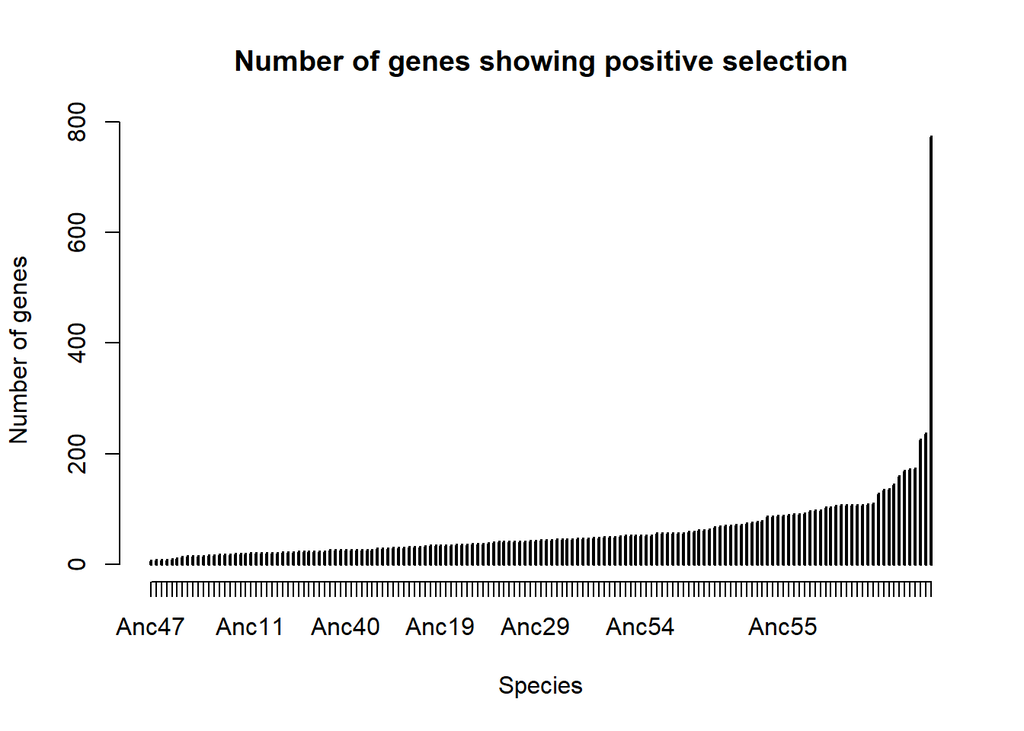

```r
#R
library(stringr)
#Selection results
sel_out <- read.table("output_sele_hmm.txt", header = T, sep = "\t")
sel_out$gene <- str_split_fixed(sel_out$gene_name, "_", 3)[,1]

#Save list of all genes used in selection analysis
#write.table(sel_out$gene, "sel_all.txt", quote = F, sep = "", row.names = F, col.names = F)
write.table(sel_out$gene[sel_out$bulbul > 0], "sel_bul.txt", quote = F, sep = "", row.names = F, col.names = F)
write.table(sel_out$gene[sel_out$kingfisher > 0], "sel_king.txt", quote = F, sep = "", row.names = F, col.names = F)
write.table(sel_out$gene[sel_out$swallow > 0], "sel_swa.txt", quote = F, sep = "", row.names = F, col.names = F)
write.table(sel_out$gene[sel_out$penguin > 0], "sel_pen.txt", quote = F, sep = "", row.names = F, col.names = F)

sel_out <- subset(sel_out, nsel_SRV > 0)
sel_out$non_target <- sel_out$nsel_SRV - sel_out$targets
sel_out$frac_target <- sel_out$targets/sel_out$nsel_SRV

all_taxa <- unlist(strsplit(sel_out$taxa,","))
plot(sort(table(all_taxa)), main="Number of genes showing positive selection", xlab="Species", ylab="Number of genes")
```

Since *Malurus cyaneus* had too many positively selected genes than all other species, we removed it from further analysis of selection.

```r
sel_out$nsel_SRV_corr <- sel_out$nsel_SRV

#Malurus cyaneus is an outlier
for (x in seq(1, nrow(sel_out))){
  if ("Malurus_cyaneus" %in% unlist(strsplit(sel_out[x,"taxa"], ","))){
    sel_out[x, "nsel_SRV_corr"] <- sel_out[x, "nsel_SRV_corr"] - 1
  }
}

sel_out$frac_target_corr <- sel_out$targets/sel_out$nsel_SRV

sel_out_targets <- subset(sel_out, frac_target_corr > 0.5)

getphyper <- function(overlap, list1, list2, pop){
  test_val <- phyper(overlap-1,list1,pop-list1,list2)
  return(test_val)
}

PopSize=nrow(sel_out_targets)
listB=length(which(sel_out_targets$bulbul>0))
listP=length(which(sel_out_targets$penguin>0))
listS=length(which(sel_out_targets$swallow>0))
listK=length(which(sel_out_targets$kingfisher>0))
#calculate whether any of these pairwise comparisons are significant using a hypergeometric test
pvals = c()
#BP
pvals = c(pvals, getphyper(length(which(sel_out_targets$bulbul > 0 & sel_out_targets$penguin > 0)), listB, listP, PopSize))
#BS
pvals = c(pvals, getphyper(length(which(sel_out_targets$bulbul > 0 & sel_out_targets$swallow > 0)), listB, listS, PopSize))
#BK
pvals = c(pvals, getphyper(length(which(sel_out_targets$bulbul > 0 & sel_out_targets$kingfisher > 0)), listB, listK, PopSize))
#SK
pvals = c(pvals, getphyper(length(which(sel_out_targets$swallow > 0 & sel_out_targets$kingfisher > 0)), listS, listK, PopSize))
#PK
pvals = c(pvals, getphyper(length(which(sel_out_targets$penguin > 0 & sel_out_targets$kingfisher > 0)), listP, listK, PopSize))
#PS
pvals = c(pvals, getphyper(length(which(sel_out_targets$penguin > 0 & sel_out_targets$swallow > 0)), listP, listS, PopSize))

p.adjust(pvals, method = "bonferroni")

gene_taxa <- read.table("gene_taxa.txt", sep = "\t", header = T)
gene_taxa_cat1 <- read.table("gene_taxa_cat1.txt", sep = "\t", header = T)
overlap <- intersect(gene_taxa$gene, sel_out_targets$gene)
overlap_cat1 <- intersect(gene_taxa_cat1$gene, sel_out_targets$gene)

#Save list of genes selected only in target species
write.table(sel_out_targets$gene, "sel_all_target.txt", quote = F, sep = "", eol = ",", row.names = F, col.names = F)
```

```r
#outgroups
sel_out_og <- read.table("output_sele_hmm_outgroup.txt", header = T, sep = "\t")
sel_out_og$gene <- str_split_fixed(sel_out_og$gene_name, "_", 3)[,1]
sel_out_og <- subset(sel_out_og, nsel_SRV > 0)
sel_out_og$non_target <- sel_out_og$nsel_SRV - sel_out_og$targets
sel_out_og$frac_target <- sel_out_og$targets/sel_out_og$nsel_SRV
sel_out_og$nsel_SRV_corr <- sel_out_og$nsel_SRV

for (x in seq(1, nrow(sel_out))){
  if ("Malurus_cyaneus" %in% unlist(strsplit(sel_out_og[x,"taxa"], ","))){
    sel_out_og[x, "nsel_SRV_corr"] <- sel_out_og[x, "nsel_SRV_corr"] - 1
  }
}

sel_out_og$frac_target_corr <- sel_out_og$targets/sel_out_og$nsel_SRV

sel_out_targets_og <- subset(sel_out_og, frac_target_corr > 0.5)

conv_gene_4 <- fisher.test(matrix(c(length(which(sel_out_targets$bulbul > 0 &
                                                   sel_out_targets$kingfisher > 0 &
                                                   sel_out_targets$swallow > 0 &
                                                   sel_out_targets$penguin > 0)),
                                  length(which(sel_out_targets_og$abulbul > 0 &
                                                   sel_out_targets_og$akingfisher > 0 &
                                                   sel_out_targets_og$aswallow > 0 &
                                                   sel_out_targets_og$apenguin > 0)),
                                  nrow(sel_out_targets)-length(which(sel_out_targets$bulbul > 0 &
                                                   sel_out_targets$kingfisher > 0 &
                                                   sel_out_targets$swallow > 0 &
                                                   sel_out_targets$penguin > 0)),
                                  nrow(sel_out_targets_og)-length(which(sel_out_targets_og$abulbul > 0 &
                                                   sel_out_targets_og$akingfisher > 0 &
                                                   sel_out_targets_og$aswallow > 0 &
                                                   sel_out_targets_og$apenguin > 0))),nrow = 2),
                                  alternative = "greater")

conv_gene_3_bsk <- fisher.test(matrix(c(length(which(sel_out_targets$bulbul > 0 &
                                                   sel_out_targets$kingfisher > 0 &
                                                   sel_out_targets$swallow > 0)),
                                  length(which(sel_out_targets_og$abulbul > 0 &
                                                   sel_out_targets_og$akingfisher > 0 &
                                                   sel_out_targets_og$aswallow > 0)),
                                  nrow(sel_out_targets)-length(which(sel_out_targets$bulbul > 0 &
                                                   sel_out_targets$kingfisher > 0 &
                                                   sel_out_targets$swallow > 0)),
                                  nrow(sel_out_targets_og)-length(which(sel_out_targets_og$abulbul > 0 &
                                                   sel_out_targets_og$akingfisher > 0 &
                                                   sel_out_targets_og$aswallow > 0))),nrow = 2),
                                  alternative = "greater")
conv_gene_3_bsk <- fisher.test(matrix(c(length(which(sel_out_targets$bulbul > 0 &
                                                   sel_out_targets$swallow > 0 &
                                                   sel_out_targets$penguin > 0)),
                                  length(which(sel_out_targets_og$abulbul > 0 &
                                                   sel_out_targets_og$aswallow > 0 &
                                                   sel_out_targets_og$apenguin > 0)),
                                  nrow(sel_out_targets)-length(which(sel_out_targets$bulbul > 0 &
                                                   sel_out_targets$swallow > 0 &
                                                   sel_out_targets$penguin > 0)),
                                  nrow(sel_out_targets_og)-length(which(sel_out_targets_og$abulbul > 0 &
                                                   sel_out_targets_og$aswallow > 0 &
                                                   sel_out_targets_og$apenguin > 0))),nrow = 2),
                                  alternative = "greater")
conv_gene_3_bpk <- fisher.test(matrix(c(length(which(sel_out_targets$bulbul > 0 &
                                                   sel_out_targets$kingfisher > 0 &
                                                   sel_out_targets$penguin > 0)),
                                  length(which(sel_out_targets_og$abulbul > 0 &
                                                   sel_out_targets_og$akingfisher > 0 &
                                                   sel_out_targets_og$apenguin > 0)),
                                  nrow(sel_out_targets)-length(which(sel_out_targets$bulbul > 0 &
                                                   sel_out_targets$kingfisher > 0 &
                                                   sel_out_targets$penguin > 0)),
                                  nrow(sel_out_targets_og)-length(which(sel_out_targets_og$abulbul > 0 &
                                                   sel_out_targets_og$akingfisher > 0 &
                                                   sel_out_targets_og$apenguin > 0))),nrow = 2),
                                  alternative = "greater")
conv_gene_3_psk <- fisher.test(matrix(c(length(which(sel_out_targets$penguin > 0 &
                                                   sel_out_targets$kingfisher > 0 &
                                                   sel_out_targets$swallow > 0)),
                                  length(which(sel_out_targets_og$apenguin > 0 &
                                                   sel_out_targets_og$akingfisher > 0 &
                                                   sel_out_targets_og$aswallow > 0)),
                                  nrow(sel_out_targets)-length(which(sel_out_targets$penguin > 0 &
                                                   sel_out_targets$kingfisher > 0 &
                                                   sel_out_targets$swallow > 0)),
                                  nrow(sel_out_targets_og)-length(which(sel_out_targets_og$apenguin > 0 &
                                                   sel_out_targets_og$akingfisher > 0 &
                                                   sel_out_targets_og$aswallow > 0))),nrow = 2),
                                  alternative = "greater")
conv_gene_2_bk <- fisher.test(matrix(c(length(which(sel_out_targets$bulbul > 0 &
                                                   sel_out_targets$kingfisher > 0)),
                                  length(which(sel_out_targets_og$abulbul > 0 &
                                                   sel_out_targets_og$akingfisher > 0)),
                                  nrow(sel_out_targets)-length(which(sel_out_targets$bulbul > 0 &
                                                   sel_out_targets$kingfisher > 0)),
                                  nrow(sel_out_targets_og)-length(which(sel_out_targets_og$abulbul > 0 &
                                                   sel_out_targets_og$akingfisher > 0))),nrow = 2),
                                  alternative = "greater")
conv_gene_2_bs <- fisher.test(matrix(c(length(which(sel_out_targets$bulbul > 0 &
                                                   sel_out_targets$swallow > 0)),
                                  length(which(sel_out_targets_og$abulbul > 0 &
                                                   sel_out_targets_og$aswallow > 0)),
                                  nrow(sel_out_targets)-length(which(sel_out_targets$bulbul > 0 &
                                                   sel_out_targets$swallow > 0)),
                                  nrow(sel_out_targets_og)-length(which(sel_out_targets_og$abulbul > 0 &
                                                   sel_out_targets_og$aswallow > 0))),nrow = 2),
                                  alternative = "greater")
conv_gene_2_bp <- fisher.test(matrix(c(length(which(sel_out_targets$bulbul > 0 &
                                                   sel_out_targets$penguin > 0)),
                                  length(which(sel_out_targets_og$abulbul > 0 &
                                                   sel_out_targets_og$apenguin > 0)),
                                  nrow(sel_out_targets)-length(which(sel_out_targets$bulbul > 0 &
                                                   sel_out_targets$penguin > 0)),
                                  nrow(sel_out_targets_og)-length(which(sel_out_targets_og$apenguin > 0 &
                                                   sel_out_targets_og$akingfisher > 0))),nrow = 2),
                                  alternative = "greater")
conv_gene_2_ks <- fisher.test(matrix(c(length(which(sel_out_targets$swallow > 0 &
                                                   sel_out_targets$kingfisher > 0)),
                                  length(which(sel_out_targets_og$aswallow > 0 &
                                                   sel_out_targets_og$akingfisher > 0)),
                                  nrow(sel_out_targets)-length(which(sel_out_targets$swallow > 0 &
                                                   sel_out_targets$kingfisher > 0)),
                                  nrow(sel_out_targets_og)-length(which(sel_out_targets_og$aswallow > 0 &
                                                   sel_out_targets_og$akingfisher > 0))),nrow = 2),
                                  alternative = "greater")
conv_gene_2_kp <- fisher.test(matrix(c(length(which(sel_out_targets$penguin > 0 &
                                                   sel_out_targets$kingfisher > 0)),
                                  length(which(sel_out_targets_og$apenguin > 0 &
                                                   sel_out_targets_og$akingfisher > 0)),
                                  nrow(sel_out_targets)-length(which(sel_out_targets$penguin > 0 &
                                                   sel_out_targets$kingfisher > 0)),
                                  nrow(sel_out_targets_og)-length(which(sel_out_targets_og$apenguin > 0 &
                                                   sel_out_targets_og$akingfisher > 0))),nrow = 2),
                                  alternative = "greater")
conv_gene_2_sp <- fisher.test(matrix(c(length(which(sel_out_targets$swallow > 0 &
                                                   sel_out_targets$penguin > 0)),
                                  length(which(sel_out_targets_og$aswallow > 0 &
                                                   sel_out_targets_og$apenguin > 0)),
                                  nrow(sel_out_targets)-length(which(sel_out_targets$swallow > 0 &
                                                   sel_out_targets$penguin > 0)),
                                  nrow(sel_out_targets_og)-length(which(sel_out_targets_og$aswallow > 0 &
                                                   sel_out_targets_og$apenguin > 0))),nrow = 2),
                                  alternative = "greater")
```

### 2.3.7 GO enrichment analysis

For GO enrichment analysis we used [PANTHER](https://www.pantherdb.org/)